# Creating images with R

Burning eyes

Bill Liu

```css
h1, h2, h3 {
  color: #6F73D2;
  font-family: 'Impact';
}

body {
  color: #114B5F;
  background-color: #D9F0FF;
  font-weight: 500;
}

a {
  color: #0DAB76;
  font-weight: bold;
  text-decoration: underline;
}
```

## Project requirements

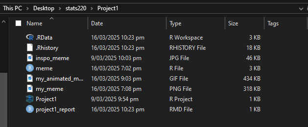

[Link to my stats220 repository](https://github.com/bliub0665/stats220)

## Inspo meme

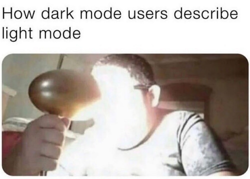

The key components of the inspo meme are the text at the top giving context, and the image on the bottom answering the text in an exaggerated and therefore hilarious manner

## My meme

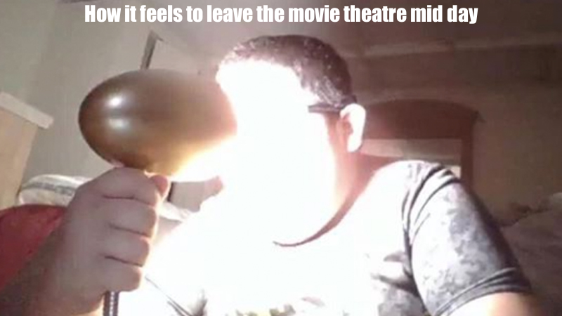

I had changed the text from the inspo meme to create a new joke while using the same punchline. This allows for there to be a different context while also retaining the humorous effect of the original image of a kid shining a lamp into his own face

## My animated meme

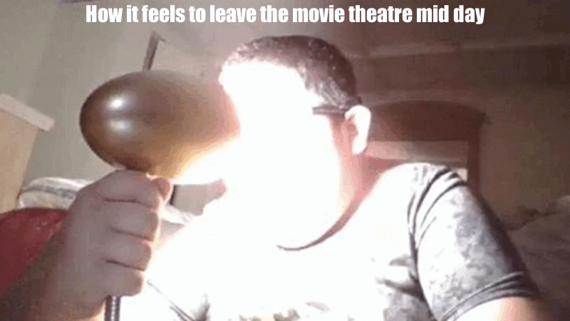

## Creativity

I had used additional functions from the {magick} package such as image_negate and image_charcoal to animate the meme to create a more exaggerated and extreme effect. I had also changed the font of headings compared to the body paragraphs so it is clear which section is a new topic. I also added an underline to my github link for it to be clear as a link as that’s how it is traditionally presented.

## Learning reflection

One important idea that I had learnt from Module 1 is that R could possibly be a very dynamic language, this is explored through the use of the {magick} package and how it could assist the user in making and editing images. With the various other packages out there I’m expecting everything to open up new doors for what people could do in R.The thing about data technologies that I want to explore further is the gathering of information/data and how we’re going to be able to interpret it using Rstudio and then presenting it in a manner where people are able to understand where the crucial information is.

## Appendix

Do not change, edit, or remove the `R` chunk included below.

If you are working within RStudio and within your Project1 RStudio project (check the top right-hand corner says “Project1”), then the code from the `meme.R` script will be displayed below.

This code needs to be visible for your project to be marked appropriately, as some of the criteria are based on this code being submitted.

```r
library(magick)

meme_image <- image_read("https://i.imgflip.com/4fdpc1.png") %>%
  image_resize("800x450") #resize and read image being used

meme <- meme_image %>%
  image_annotate(
    text = "How it feels to leave the movie theatre mid day", #add text to meme
    color = "#ffffff", #color white
    size = 30, #smaller size to fit image
    font = "Impact", #impact font
    gravity = "north" #put text at top of image
    )
image_write(meme, "my_meme.png") #save the image as a png

frame1 <- meme_image %>% #creating first frame
  image_annotate(
    text = "How it feels to leave the movie theatre mid day", #text
    color = "#ffffff", #color white
    size = 30, #smaller size to fit image
    font = "Impact", #impact font
    gravity = "north" #put text at top of image
  )

frame2_image <- image_charcoal(meme_image) #put an effect on the image
frame2 <- frame2_image %>%
  image_annotate(
    text = "How it feels to leave the movie theatre mid day", #text
    color = "#000000", #color black
    size = 30, #smaller size to fit image
    font = "Impact", #impact font
    gravity = "north" #put text at top of image
  )

frame3_image <- image_read("https://i.imgflip.com/28rgrp.jpg") %>%
  image_resize("800x450") #new image on frame 3 and resizing it
frame3 <- frame3_image %>%
  image_annotate(
    text = "How it feels to leave the movie theatre mid day", #text
    color = "#ffffff", #color white
    size = 30, #smaller size to fit image
    font = "Impact", #impact font
    gravity = "north" #put text at top of image
  )

frame4_image <- image_negate(frame3_image) #filter frame 3's image for 4
frame4 <- frame4_image %>%
  image_annotate(
    text = "How it feels to leave the movie theatre mid day", #text
    color = "#000000", #color black
    size = 30, #smaller size to fit image
    font = "Impact", #impact font
    gravity = "north" #put text at top of image
  )

frames <- c(frame1, frame2, frame3, frame4) #create vector with all 4 frames
animation <- image_animate(frames, fps = 1) #animating by using the vectors
image_write(animation, "my_animated_meme.gif") #save animation as gif
```